# 305.1. Variable star light curves

For the Rubin Science Platform at data.lsst.cloud.  
Data Release: [Data Preview 1](https://dp1.lsst.io/)  
Container Size: large  
LSST Science Pipelines version: r29.2.0  
Last verified to run: 2025-11-03  
Repository: github.com/lsst/tutorial-notebooks

**Learning objective:** Learn how to extract and plot a light curve for a variable star from DP1.

**LSST data products:** `ForcedSourceOnDiaObject`, `DiaObject`, `Visit`

**Packages:** `matplotlib`, `numpy`, `lsst.rsp`, `lsst.utils.plotting`

**Credit:** Originally developed by the Rubin Community Science team. Please consider acknowledging them if this notebook is used for the preparation of journal articles, software releases, or other notebooks.

**Get Support:** Everyone is encouraged to ask questions or raise issues in the [Support Category](https://community.lsst.org/c/support) of the Rubin Community Forum. Rubin staff will respond to all questions posted there.

## 1. Introduction

This notebook demonstrates how to obtain and plot light curves of a variable star captured in Data Preview 1 (DP1). Time series are extracted for forced photometry on difference images and direct ("visit") images.

**Related tutorials:** The 100-level tutorials on the TAP service, and the 200-level tutorials on the difference image analysis (DIA) catalogs.

### 1.1. Import packages

Import `numpy`, a fundamental package for scientific computing with arrays in Python (numpy.org), and `matplotlib`, a comprehensive library for data visualization ([matplotlib.org](https://matplotlib.org/); [matplotlib gallery](https://matplotlib.org/stable/gallery/index.html)). Also import the `units` module from [Astropy](https://www.astropy.org/), which will be used to convert fluxes to magnitudes.

From the `lsst` package, import the module for accessing the Table Access Protocol (TAP) service, and some plotting utilities.

```python
import matplotlib.pyplot as plt
import numpy as np
import astropy.units as u

from lsst.rsp import get_tap_service

from lsst.utils.plotting import (get_multiband_plot_colors,
                                 get_multiband_plot_symbols)
```

### 1.2. Define parameters and functions

Create an instance of the TAP service, and assert that it exists.

```python
service = get_tap_service("tap")
assert service is not None
```

Define filter names, plot markers, and colors for plotting.

```python
filter_names = ['u', 'g', 'r', 'i', 'z', 'y']
filter_colors = get_multiband_plot_colors()
filter_symbols = get_multiband_plot_symbols()
```

## 2. Retrieve light curve data

Obtain light curve data from the `ForcedSourceOnDiaObject` table, which contains forced PSF photometry for *all* difference images as well as non-difference images (`visit_images`). The relevant table columns for plotting light curves are:

- `psfDiffFlux`: Forced PSF photometry on difference images at DiaObject position
- `psfFlux`: Forced PSF photometry on `visit_images` at DiaObject position
- `diaObjectId`: Unique DiaObject identifier
- `band`: Filter associated with flux measurement
- `visit`: Identifier of the visit where the forced photometry was measured (used for table JOIN on `Visit` table)

The date information `expMidptMJD`, which is mid-point time for the visit in MJD, can be obtained from the `Visit` table.

The units used to plot the light curve are in flux (nJy) and not magnitudes since the negative flux measurements would be omitted when converting to magnitudes.

### 2.1 Look up diaObjectId from coordinates

The first step to obtain light curve data is to define the coordinates (ra and dec) of a variable star captured in DP1: Gaia DR3 2912281258855051520.

```python
ra_var = 94.9226329830
dec_var = -25.2318482104
```

Define a 0.5 arcsecond search radius, and convert it to degrees.

```python
search_rad = 0.5/3600
```

Search at this position in the `DiaObject` table to retrieve the `diaObjectId` of the corresponding object.

```python
query = "SELECT ra, dec, diaObjectId "\
        "FROM dp1.DiaObject "\
        "WHERE CONTAINS(POINT('ICRS', ra, dec), "\
        "CIRCLE('ICRS', " + str(ra_var) + ", "\
        + str(dec_var) + ", " + str(search_rad) + ")) = 1"
print(query)
```

```
SELECT ra, dec, diaObjectId FROM dp1.DiaObject WHERE CONTAINS(POINT('ICRS', ra, dec), CIRCLE('ICRS', 94.922632983, -25.2318482104, 0.0001388888888888889)) = 1
```

```python
job = service.submit_job(query)
job.run()
job.wait(phases=['COMPLETED', 'ERROR'])
print('Job phase is', job.phase)
if job.phase == 'ERROR':
    job.raise_if_error()
```

```
Job phase is COMPLETED
```

Fetch the results of the TAP search in table form and print the unique entries for `diaObjectId` in the output table.

```python
assert job.phase == 'COMPLETED'
DiaObj = job.fetch_result().to_table()
print(np.unique(DiaObj['diaObjectId']))
```

```
   diaObjectId
------------------
614435753623027782
```

### 2.2. Search based on diaObjectId

Provide this `diaObjectId` as a constraint to a TAP query to obtain the time series from `ForcedSourceOnDiaObject`. The use of an ID in this manner is always the recommended way to access data from a ForcedSource table.

```python
DiaObjID = DiaObj['diaObjectId'][0]
```

```python
query = "SELECT fsodo.coord_ra, fsodo.coord_dec, "\
        "fsodo.diaObjectId, fsodo.visit, fsodo.band, "\
        "fsodo.psfDiffFlux, fsodo.psfDiffFluxErr, "\
        "fsodo.psfFlux as psfFlux, fsodo.psfFluxErr, "\
        "vis.expMidptMJD "\
        "FROM dp1.ForcedSourceOnDiaObject as fsodo "\
        "JOIN dp1.Visit as vis ON vis.visit = fsodo.visit "\
        "WHERE fsodo.diaObjectId = "+str(DiaObjID)
print(query)
```

[output not shown]

Run the TAP query.

```python
job = service.submit_job(query)
job.run()
job.wait(phases=['COMPLETED', 'ERROR'])
print('Job phase is', job.phase)
if job.phase == 'ERROR':
    job.raise_if_error()
```

```
Job phase is COMPLETED
```

Fetch the results of the TAP search in table form and print the number of rows.

```python
assert job.phase == 'COMPLETED'
forced_source = job.fetch_result().to_table()
print(len(forced_source))
```

```
225
```

Uncomment the following to view the table.

```python
# forced_source
```

Count the number of visits in each band and print them to the screen.

```python
for band in filter_names:
    print(f"{band}: {np.sum((forced_source['band'] == band))} visits")
```

```
u: 20 visits
g: 66 visits
r: 71 visits
i: 17 visits
z: 43 visits
y: 8 visits
```

## 3. Plot the light curve

### 3.1. Plot flux vs. time

Plot the forced PSF photometry on the difference images and the direct (`visit_image`) images covering the variable star.

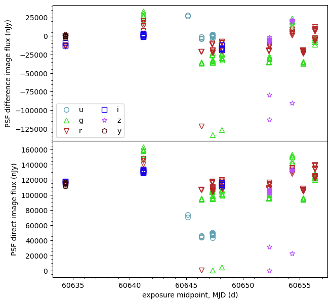

```python
fig, (ax1, ax2) = plt.subplots(2, 1, figsize=(7, 7), sharex=True)
fig.subplots_adjust(wspace=0, hspace=0)

for band in filter_names:
    pickband = np.where(forced_source['band'] == band)
    ax1.plot(forced_source[pickband]['expMidptMJD'], forced_source[pickband]['psfDiffFlux'],
             marker=filter_symbols[band], color=filter_colors[band],
             label=f"{band}", markersize=7, linestyle='none', fillstyle='none')
    ax2.plot(forced_source[pickband]['expMidptMJD'], forced_source[pickband]['psfFlux'],
             marker=filter_symbols[band], color=filter_colors[band], linestyle='none',
             markersize=7, fillstyle='none')

ax1.set_ylabel('PSF difference image flux (nJy)')
ax2.set_ylabel('PSF direct image flux (nJy)')
ax2.set_xlabel('exposure midpoint, MJD (d)')
ax1.minorticks_on()
ax2.minorticks_on()
ax1.legend(ncols=2)
plt.show()
```

> **Figure 1:** Forced PSF photometry of a variable star in DP1 from the `ForcedSourceonDiaObject` table. The two panels represent the flux measured on the difference images (top) and the "direct" images (`visit_image` dataset type).

### 3.2. Plot flux vs. phase

Use the known period of the variable star to "phase-fold" the light curve.

Define the period in days for the SX Phe star from [Carlin et al. 2025](https://ui.adsabs.harvard.edu/abs/2025RNAAS...9..161C/abstract).

```python
period = 0.07670835
```

Place each point of the time series into the correct phase of the variable's pulsation. Use the time of maximum $r$-band flux as zero phase.

```python
pickr = np.where(forced_source['band'] == 'r')
ind_max = np.argmax(forced_source['psfFlux'][pickr])
t0 = forced_source['expMidptMJD'][pickr][ind_max]
mjd_norm = (forced_source['expMidptMJD'] - t0) / period
phase = np.mod(mjd_norm, 1.0)
```

Plot the phase-folded light curves in difference-image and direct-image flux, then plot the curve in magnitudes (measured from the direct images).

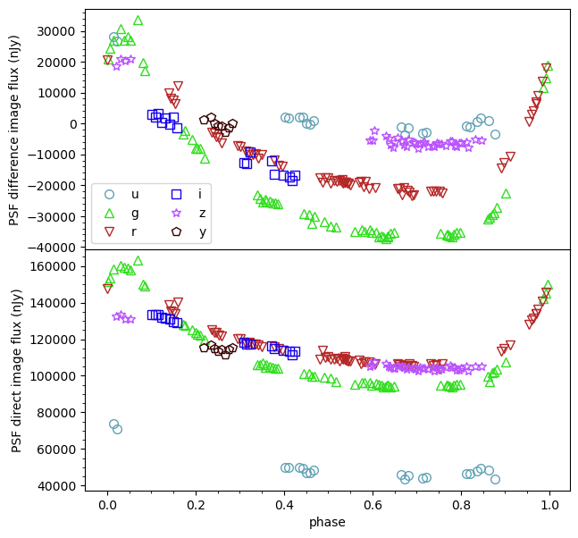

```python
fig, (ax1, ax2) = plt.subplots(2, 1, figsize=(7, 7), sharex=True)
fig.subplots_adjust(wspace=0, hspace=0)

for band in filter_names:
    pickband = np.where((forced_source['band'] == band)
                        & (forced_source['psfDiffFlux'] > -50000))
    ax1.plot(phase[pickband], forced_source[pickband]['psfDiffFlux'],
             marker=filter_symbols[band], color=filter_colors[band],
             label=f"{band}", markersize=7, linestyle='none', fillstyle='none')
    ax2.plot(phase[pickband], forced_source[pickband]['psfFlux'],
             marker=filter_symbols[band], color=filter_colors[band], linestyle='none',
             markersize=7, fillstyle='none')

ax1.set_ylabel('PSF difference image flux (nJy)')
ax2.set_ylabel('PSF direct image flux (nJy)')
ax2.set_xlabel('phase')
ax1.minorticks_on()
ax2.minorticks_on()
ax1.legend(ncols=2)
plt.show()
```

> **Figure 2:** Forced PSF photometry of a variable star in DP1 from the `ForcedSourceonDiaObject` table, with each point placed into its observed phase in the variable's pulsation cycle. The two panels represent the flux measured on the difference images (top) and the "direct" images (`visit_image` dataset type).

### 3.3. Plot magnitude vs. phase

Filter out catalog entries with spurious negative flux measurements. Then convert the direct image forced fluxes to magnitudes, and plot a light curve.

```python
forced_source = forced_source[forced_source['psfFlux'] > 0]

mag = forced_source['psfFlux'].to(u.ABmag).value
```

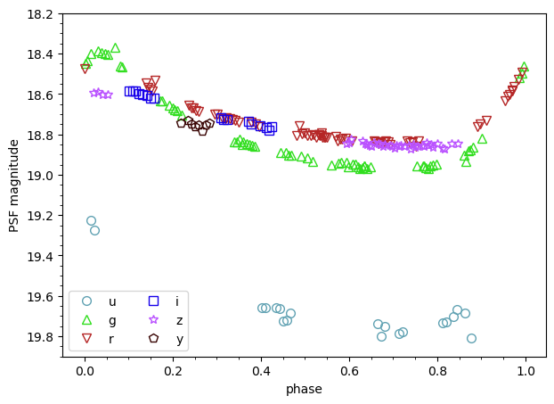

```python
fig, ax = plt.subplots(1, 1, figsize=(7, 5))

for band in filter_names:
    pickband = np.where(forced_source['band'] == band)
    ax.plot(phase[pickband], mag[pickband],
            marker=filter_symbols[band], color=filter_colors[band],
            label=f"{band}", markersize=7, linestyle='none', fillstyle='none')

ax.set_ylabel('PSF magnitude')
ax.set_xlabel('phase')
ax.minorticks_on()
ax.legend(ncols=2, loc='lower left')
plt.ylim(19.9, 18.2)
plt.show()
```

> **Figure 3:** Forced PSF photometry, in AB magnitudes, of a variable star in DP1 from the direct-image measurements in the `ForcedSourceonDiaObject` table. Each point is placed at its observed phase in the variable's pulsation cycle.